# Data Science 112 Final Report

Author

Val Tlahuice , Kampe Rushoka, Gabriella Moreno

## Introduction

Wage inequality has long been a defining feature of the United States labor market, reflecting broader patterns of social, economic, and political inequality. Differences in earnings across individuals are shaped not only by education and skills, but also by structural factors such as race and gender. These disparities have significant implications for economic security, social mobility, and overall well-being.

By using data from the Economic Policy Institute, this study asks: How have demographics, specifically sex and race and different levels of educational attainment affected Americans’ median wages between 1973 to 2022? By analyzing wage trends across demographic and educational categories, this research seeks to identify which identities have benefited most from economic growth and which continue to experience structural disadvantages in the labor market. Additionally, look into the economic trajectory of intersection of identities as well. This study could help better explain historical structural inequality and as well justify more equitable public policies such as pay equity regulations, affirmative action, and equitable access to education.

Drawing on existing theories of structural privilege and racial economic disparities, this study advances several hypotheses about wage inequality across race, gender, and education ( Pager and Shepherd 2008; Wilson 1996; Blau and Kahn 2017). First, we expected that white men with advanced levels of education will consistently earn the highest median wages over time, reflecting their compounded advantages of race, gender, and educational credentials. Second, the analysis anticipates substantial wage differences between white workers and non-white identities (Black and Hispanic Identities).

## Data background

The Wages by Education dataset was sourced from Kaggle and provides hourly wages by the highest level of education attained for wage and salary workers aged 16 and older in the USA. The data was disaggregated by demographic factors including gender (Male and Female) and race/ ethnicity (White, Black, and Hispanic). All wages are adjusted to 2022 dollars using the CPI-U-RS index to account for inflation. The dataset spans from 1973 to 2022 and originates from the Economic Policy Institute’s State of Working America Data Library (Kaggle. (n.d.)).

After cleaning, the dataset contains approximately 4,500 aggregated wage records and includes five main variables: race, gender, education level, wages and median wages. During preprocessing, the data was joined with a second Kaggle dataset (also sourced from the EPI through Kaggle) containing median and average wage measures (Kaggle. (n.d.)). We observed that average wages were sometimes unusually high, likely influenced by extreme outliers in the dataset. To minimize the impact of these outliers, we focused on median wages, which better represent the typical earnings of each group.

Data quality checks revealed no missing wage values, though some demographic identities are not represented in the dataset, including Asian, Indigenous, non-binary, and transgender individuals.In our wrangling, Demographic labels were standardized, and the dataset was pivoted to a long format, producing one row per demographic per year.

```
## # A tibble: 8 × 3
##    year demographic      Wages
##   <dbl> <chr>            <dbl>
## 1  1973 median            19.8
## 2  1973 men_median        24
## 3  1973 women_median      15.1
## 4  1973 white_median      20.5
## 5  1973 black_median      16.0
## 6  1973 hispanic_median   16.4
## 7  1973 white_men_median  25.0
## 8  1973 black_men_median  19.3
```

## Data insights

### Median Wage Differences across Education Levels

When first looking at the median wages across the different educational levels in Figure 1 , we see interesting findings. Following our intuition, the higher the education level the higher the median wage of that educational level group, and that has been consistent across the years from 1973-2022. Over the years, we can see that the median wage of those with a high school diploma or less, earned the lowest wages, roughly between $15 and $25 per hour. Whereas, the median wage of those with advanced degrees was generally between $35 and $55 per hour, across the years. Additionally, Advanced-degree and bachelor degree median wages seems to have been growing at the fastest rate across all educational levels, whereas the lower educational levels have experienced low to no median wage growth. Therefore, this graph shows increasing return to education, suggesting that education could be an important factor determining wages.

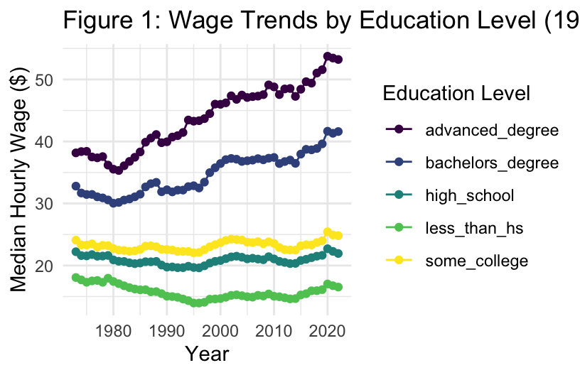

Figure 1 is a scatter plot showing median hourly wages from 1973 to 2022 by education level.

### Median Wage Differences Accross Gender

According to Figure 2, men’s median wages are consistently higher than women’s median wages across the entire period shown. However, the gap between men’s and women’s wages has narrowed substantially over time. In 1973, the median wage difference was approximately $10 per hour, with men earning close to $25 per hour and women earning around $15 per hour. By 2022, this gap had decreased to roughly $5 per hour, as men’s median wages rose to about $26 per hour while women’s median wages increased to nearly $21 per hour. This pattern indicates significant progress toward wage convergence, though a persistent gender wage gap remains.

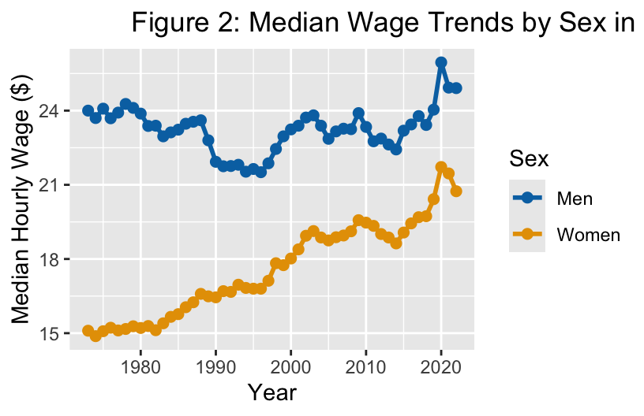

Figure 2 is a scatterplot of median hourly wages ($) by sex over time

### Median Wage Differences Accross Race

Figure 3 reveals persistent racial wage disparities over time. Median hourly wages for Black and Hispanic workers follow closely aligned trajectories throughout the period, while White workers’ median wages remain consistently higher. Notably, White workers reached a median wage of approximately $20 per hour by the early 1980s, whereas Black and Hispanic workers did not reach this same wage level until around 2020. This roughly forty-year gap illustrates how racial wage inequality has persisted across decades, even as median wages increased for all groups in real terms.

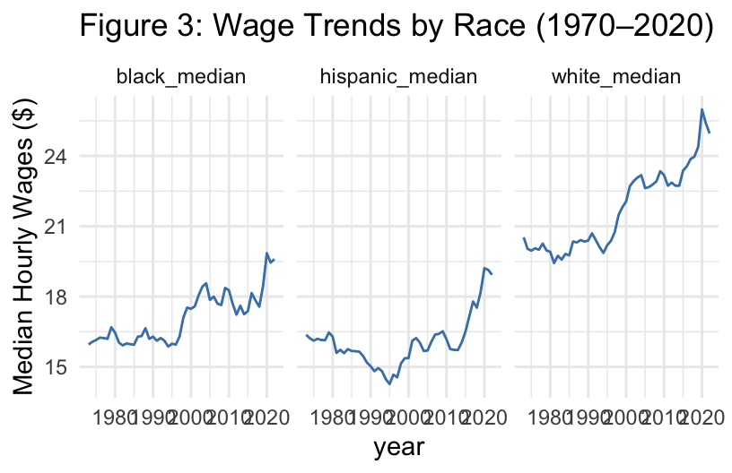

Figure 3 displays median hourly wage trends by race (White, Black, and Hispanic) from 1973 to 2022.

## Median wages accross Intersection of Identities

Now after looking at the median wages of each identity group over time, our study was interested in looking into the intersection of multiple identities and how that has affected the changes in median wages over time

### Median wages accross Education levels and Sex

Figure 4 is a scatter plot of the median hourly wages by educational attainment for men and for women over time. The plot shows that for both sexes, higher educational attainment is consistently associated with higher median wages. However, when comparing the same education levels, men’s median wages were consistently and significantly higher than women’s median wages. For example, in 2022when looking at the median wage for men with advanced degrees, it was well above 60$ an hour, whereas the median wage for women with the same degree was around 45$.

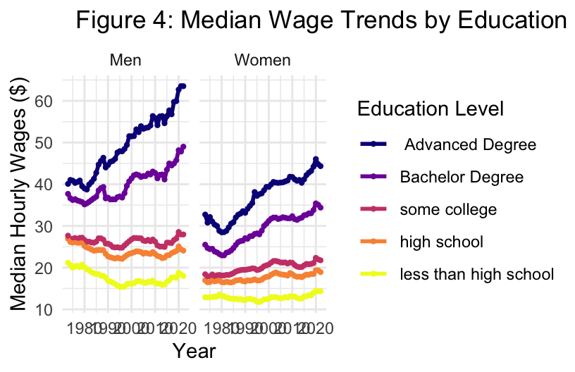

Figure 4 displays a scatterplot of median hourly wages from the EPI by educational attainment for men and women over time.

### Median Wages Accross Gender and Race differences

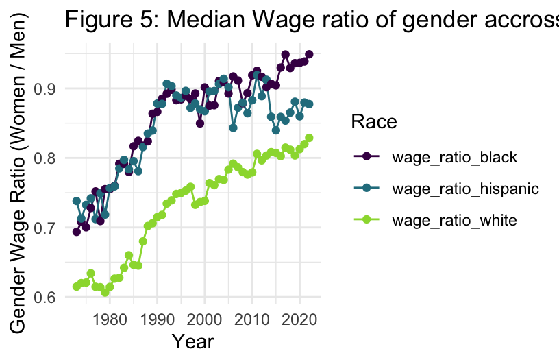

Figure 5 shows gender wage ratios by race over time. Through a scatterplot, the plot illustrates how the ratio of women’s to men’s median wages has changed across racial groups, highlighting both progress toward wage convergence and persistent racial disparities

### Median Wages Accross Gender, Race and Educational differences.

Figures 6 and 7 present kernel density plots of wage distributions by gender and race at two levels of educational attainment. Figure 6 displays wage distributions for individuals with less than a high school education, with separate facets for Black, Hispanic, and White workers and gender indicated by color. At this education level, there is minimal overlap between men’s and women’s wage distributions for Black and Hispanic workers and virtually no overlap for White workers, indicating substantial gender wage differences, particularly among White individuals with lower educational attainment. In contrast, Figure 7 shows wage distributions for individuals with advanced degrees, where there is considerably more overlap between men’s and women’s distributions across all racial groups. The greatest overlap appears among Black workers, suggesting more similar wages between men and women at higher education levels, while White and Hispanic workers continue to exhibit noticeable gender wage differences. Taken together, these figures suggest that higher education narrows gender wage disparities, but does not eliminate them, and that the extent of convergence varies across racial groups.

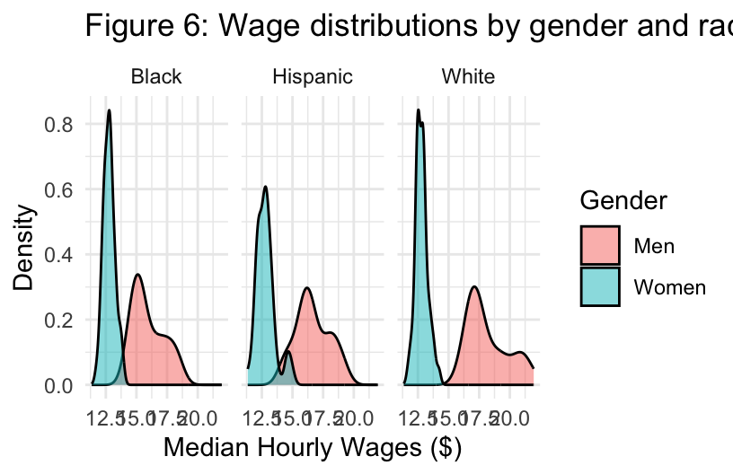

Figure 6 shows kernel density plots of median hourly wages by gender and race for individuals with less than a high school education.

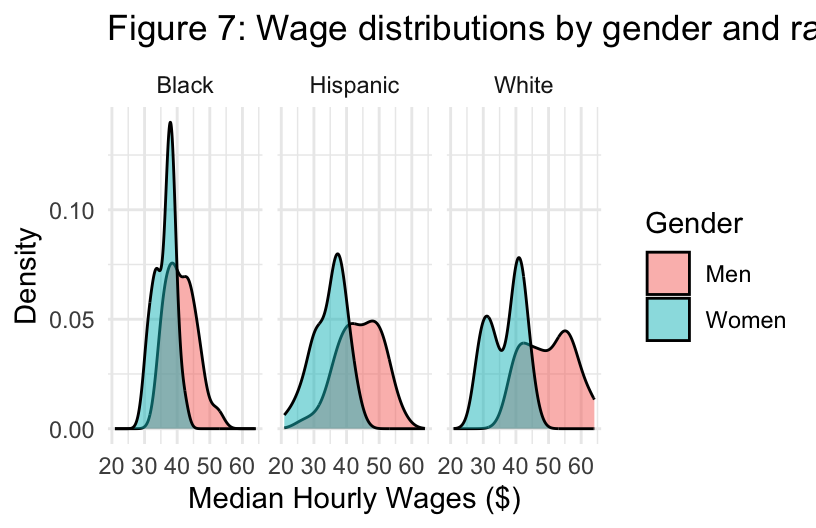

Figure 7 presents kernel density plots of median hourly wages by gender and race for individuals with advanced degrees.

## References :

Blau, Francine D., and Lawrence M. Kahn. 2017. The Gender Wage Gap: Extent, Trends, and Explanations. Journal of Economic Literature.

Crenshaw, Kimberlé. 1989. Demarginalizing the Intersection of Race and Sex. University of Chicago Legal Forum.

Kaggle. (n.d.). Wages by education in the USA 1973–2022 [Data set]. Kaggle. https://www.kaggle.com/datasets/asaniczka/wages-by-education-in-the-usa-1973-2022

Pager, Devah, and Hana Shepherd. 2008. The Sociology of Discrimination. Annual Review of Sociology.

Wilson, William Julius. 1996. When Work Disappears.